# Model Submission Tutorial in R

An Allstate Data Scientist

2/15/2017

## The scope of this tutorial

Building a good predictive model is equal parts science and art, and this tutorial will disappoint on both fronts. It will do so by not only leaving out the very basic things that need to be done to construct a model you can trust (things like appropriately validating your model), but also by not doing things that need to be done to construct a good model (meaningful features, parameter tuning).

Think of this tutorial as the shortest path from the input file that has been provided for the hackathon, to a file that you can submit to the leaderboard and get a score back. This tutorial is a starting point; it’s mission is to clarify some aspects of the data that may otherwise be less than obvious.

## Building the submission model

Let’s load some of the libraries that we will need for this tutorial. If you don’t have one or more of these libraries installed, take a look at the `install.packages` function in R.

```r
library(data.table) # tutorial assumes  v1.9.7
library(gbm) # CRAN v2.1.1
```

Once the libraries are loaded, let’s load the data. I have assumed that the data is present inside the `data` directory. If you download and save the data elsewhere, you will likely need to replace `./../data/train.csv` by `/path/to/your/data/train.csv`.

```r
data_all <- fread('./../data/train.csv')
ids_test <- fread('./../data/test.csv')
```

Let’s examine `data_all` and `ids_test` to make sure that the data has come in as expected.

```r
data_all
```

```
##                                                                        id
##       1: 00005408fb82819bf6eef036180ce1d28ca64ac455378824a882a80ed8f99bb6
##       2: 00005408fb82819bf6eef036180ce1d28ca64ac455378824a882a80ed8f99bb6
##       3: 00005408fb82819bf6eef036180ce1d28ca64ac455378824a882a80ed8f99bb6
##       4: 00005408fb82819bf6eef036180ce1d28ca64ac455378824a882a80ed8f99bb6
##       5: 000061e45fb216f4ad7fbc0cd86f620441a3091005eeb6fc76e1f71fdde1ecbc
##      ---
## 1122003: ffffef602fe218bd6b257abbbc9368d047488eea5a81351c89836da1496c75f2
## 1122004: ffffef602fe218bd6b257abbbc9368d047488eea5a81351c89836da1496c75f2
## 1122005: ffffff624a6c252ba2ba85d73f46b75889d2cb295e0bdf290704c7ddd223982d
## 1122006: ffffff624a6c252ba2ba85d73f46b75889d2cb295e0bdf290704c7ddd223982d
## 1122007: ffffff624a6c252ba2ba85d73f46b75889d2cb295e0bdf290704c7ddd223982d
##          timestamp event
##       1:         1 36003
##       2:         2 36003
##       3:         3 30018
##       4:         4 36003
##       5:         5 30021
##      ---
## 1122003:   1222872 30021
## 1122004:   1222873 30027
## 1122005:   1222875 30021
## 1122006:   1222876 30018
## 1122007:   1222877 30018
```

```r
ids_test
```

```
##                                                                       id
##      1: 0001da55d168196bf25f06a497b5cf414126542f4d357d61b8203d3b2c9eb4e5
##      2: 00024eca1053d4268df5c6d3308f0d008cf5e2678c443f46f83dd8a7714462c6
##      3: 000273e55809afd4a9ac4fb9175effe5d0ea449ed37e7c924af3f993b2d3e14b
##      4: 0002bd1d73c326ad6e337a5687f6787b055f13079d5c52ef5d21321ea233fa34
##      5: 00030b6d5b8013bcb9bb23a9bccf394d7b361a01d0d6b70de5ffa99786d49b06
##     ---
## 100866: fffdc36a3362aea6217598bcd05dad12fe425709af08370649461db448e803c3
## 100867: fffe08c56ff7b96b2c6602ddf2ffdd7ef151ae42836f14d12ce3e487aa29c6e3
## 100868: fffec7db7e3ef648450cef467d8c5e6ca29f2f70cb1b92353ae0344d217e22a4
## 100869: ffff88c2041f637a2ab5f100c3a614a742f4d5956819c6ce07269747e5ddc5d2
## 100870: ffffef602fe218bd6b257abbbc9368d047488eea5a81351c89836da1496c75f2
```

In order to create a model, I will need to count how many times each event has occurred on a given `id`. The next piece of code creates a dummy counter to assist with that task.

```r
data_all[, dummy_counter:=1]
```

The next few sections walk through the bulk of the model building exercise.

### 1. Find the first/last event for each policy in training data

```r
data_train <- subset(data_all, !(id %in% ids_test$id))

# find the first/last event for each policy in training data
data_train[, max_timestamp_by_policy:=max(timestamp), by=id]
data_train[, min_timestamp_by_policy:=min(timestamp), by=id]
```

### 2. Create the target variable for the model

To do this, we create a dataset that contains the last event for each policy. This will get merged onto the training frame we create by the `id`.

```r
data_train_last_element = subset(data_train, timestamp == max_timestamp_by_policy)
data_train_last_element$timestamp = NULL
data_train_last_element$dummy_counter = NULL
data_train_last_element$max_timestamp_by_policy = NULL
data_train_last_element$min_timestamp_by_policy = NULL
setnames(data_train_last_element, "event", "last_event")
```

### 3. Create some features for the model

One possible feature is the first event in the sequence per `id`. To create this feature, we pick the first event per `id`, isolate that in a separate data table, and join that back onto our final frame by `id`.

```r
data_train_first_element = subset(data_train, timestamp==min_timestamp_by_policy)
data_train_first_element$timestamp = NULL
data_train_first_element$dummy_counter = NULL
data_train_first_element$max_timestamp_by_policy = NULL
data_train_first_element$min_timestamp_by_policy = NULL
setnames(data_train_first_element, "event", "first_event")
```

The next feature to create is the count of how many times an event has happened on an `id`. This is where our `dummy_counter` variable comes in handy. One thing to note: the last event on a policy on the training data is the target variable, and shouldn’t be included in the counts.

```r
# featurize data, without the last element, by looking at counts of events
data_train_allButLast <- subset(data_train, timestamp != max_timestamp_by_policy)
data_train_ohe <- dcast(data_train_allButLast,
                        id ~ event,
                        fun.aggregate=sum,
                        value.var="dummy_counter")
```

Yet another feature is the total number of events that occurred (not including, obviously, the last event).

```r
# create a feature that counts how many events occured in total before the last event
data_train_ohe[, total_events:=apply(data_train_ohe[, -c("id"), with=FALSE], 1, sum)]
```

By this point, we’ve done a bunch of transformations, so let’s examine the `data_train_ohe` variable.

```r
data_train_ohe
```

```
##                                                                       id
##      1: 00005408fb82819bf6eef036180ce1d28ca64ac455378824a882a80ed8f99bb6
##      2: 000061e45fb216f4ad7fbc0cd86f620441a3091005eeb6fc76e1f71fdde1ecbc
##      3: 00008faca7acd5b2edf91b274eedc88e90b1de3b4003f93b67c20d425a29ee8d
##      4: 0000b953a8b26886a7086673d8d1b7bd78efe139775728544a3cee2e7cf95a27
##      5: 00015a0e069313122a1e4043c63625839dcb634b7de275e5fc076d1da46f0aa1
##     ---
## 236127: ffff8031cfb7ac408b3f96c466cf8c0c4edbeea99385deb407b6c5367cc2beab
## 236128: ffffc10c4256028f013e9d13f870d6c8cf9fb341e9b9088766bc2c3f190ddc12
## 236129: ffffec8f1f9bfb674766b6b8cdd517b04b52a29aac79c65fbe63c02d80aff1f1
## 236130: ffffecdfe805729a9f0c8ccef6722d9421ba0e710e427c556dd87d460a400d42
## 236131: ffffff624a6c252ba2ba85d73f46b75889d2cb295e0bdf290704c7ddd223982d
##         30018 30021 30024 30027 30039 30042 30045 30048 36003 45003
##      1:     1     0     0     0     0     0     0     0     2     0
##      2:     0     1     0     1     0     0     0     0     0     0
```

[output cut: 21 more lines]

This is starting to look good. We should add back the first event variable that we had previously created.

```r
data_train_ohe <- merge(data_train_ohe, data_train_first_element, by=c("id"))
data_train_ohe$first_event <- as.factor(data_train_ohe$first_event)
```

And we should add back the last event variable that we created; remember, this isn’t a feature for the model, but the target that we want to learn.

```r
data_train_merged <- merge(data_train_ohe, data_train_last_element, by=c("id"))
```

Our latest variable, `data_train_merged` looks like it has everything we need. We’ll take a look at the variable, and if all looks good, we’ll move on to training the model.

```r
data_train_merged
```

```
##                                                                       id
##      1: 00005408fb82819bf6eef036180ce1d28ca64ac455378824a882a80ed8f99bb6
##      2: 000061e45fb216f4ad7fbc0cd86f620441a3091005eeb6fc76e1f71fdde1ecbc
##      3: 00008faca7acd5b2edf91b274eedc88e90b1de3b4003f93b67c20d425a29ee8d
##      4: 0000b953a8b26886a7086673d8d1b7bd78efe139775728544a3cee2e7cf95a27
##      5: 00015a0e069313122a1e4043c63625839dcb634b7de275e5fc076d1da46f0aa1
##     ---
## 236127: ffff8031cfb7ac408b3f96c466cf8c0c4edbeea99385deb407b6c5367cc2beab
## 236128: ffffc10c4256028f013e9d13f870d6c8cf9fb341e9b9088766bc2c3f190ddc12
## 236129: ffffec8f1f9bfb674766b6b8cdd517b04b52a29aac79c65fbe63c02d80aff1f1
## 236130: ffffecdfe805729a9f0c8ccef6722d9421ba0e710e427c556dd87d460a400d42
## 236131: ffffff624a6c252ba2ba85d73f46b75889d2cb295e0bdf290704c7ddd223982d
##         30018 30021 30024 30027 30039 30042 30045 30048 36003 45003
##      1:     1     0     0     0     0     0     0     0     2     0
##      2:     0     1     0     1     0     0     0     0     0     0
```

[output cut: 21 more lines]

### 4. Training a model

Ok, so things looks good so far. Let’s train a basic model.

```r
# train a gbm model
# WARNING: Run time can exceed 10-15 minutes. For faster run times, lower n.trees=10
model <- gbm(last_event ~ . - id,
             distribution="multinomial",
             data=data_train_merged,
             interaction.depth=5,
             n.trees=100,
             shrinkage=0.1,
             train.fraction=0.8,
             verbose=TRUE)
```

```
##      1        2.3026          2.3026     0.1000    0.3734
##      2        2.0976          2.0968     0.1000    0.2326
##      3        1.9702          1.9690     0.1000    0.1674
##      4        1.8786          1.8771     0.1000    0.1297
##      5        1.8076          1.8061     0.1000    0.1031
##      6        1.7513          1.7497     0.1000    0.0865
##      7        1.7041          1.7023     0.1000    0.0707
##      8        1.6656          1.6638     0.1000    0.0592
##      9        1.6332          1.6313     0.1000    0.0476
##     10        1.6070          1.6050     0.1000    0.0420
##     20        1.4838          1.4815     0.1000    0.0090
##     40        1.4381          1.4361     0.1000    0.0014
##     60        1.4253          1.4240     0.1000    0.0003
##     80        1.4189          1.4182     0.1000    0.0002
##    100        1.4151          1.4153     0.1000    0.0002
```

Let’s draw some basic diagnostic plots for the model.

```r
gbm.perf(model)
```

```
## Using test method...
```

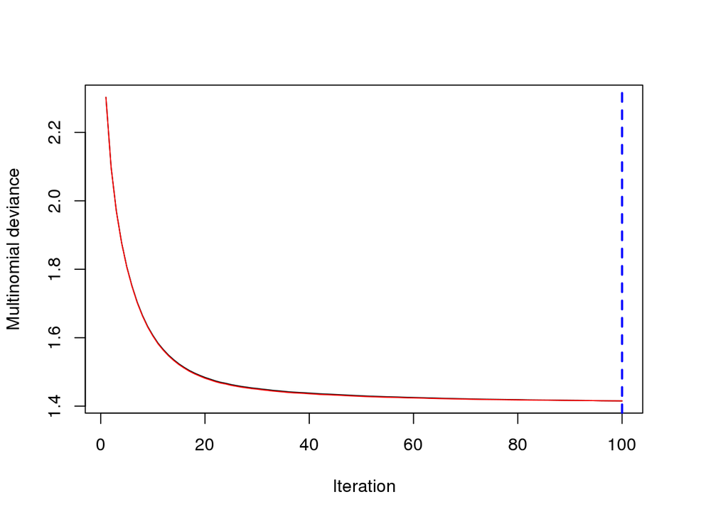

```
## [1] 100
```

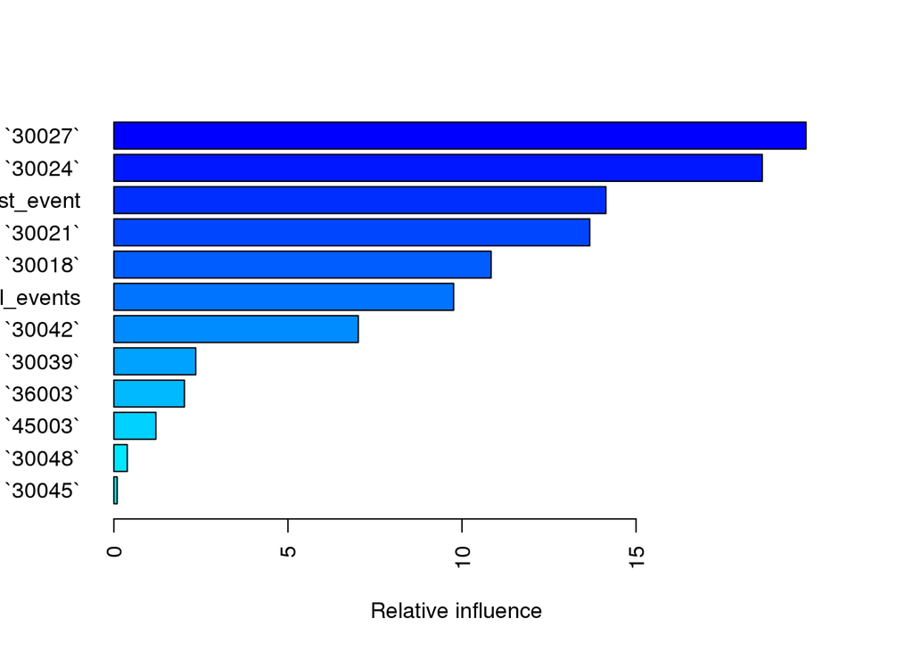

```
##                       var     rel.inf
## `30027`           `30027` 19.88318601
## `30024`           `30024` 18.62647503
## first_event   first_event 14.13469831
## `30021`           `30021` 13.67125451
## `30018`           `30018` 10.83591299
## total_events total_events  9.76004908
## `30042`           `30042`  7.02165583
## `30039`           `30039`  2.35291228
## `36003`           `36003`  2.02671157
## `45003`           `45003`  1.20703935
## `30048`           `30048`  0.38557886
## `30045`           `30045`  0.09452618
```

```r
summary(model, las=2)
```

## Scoring the model on the test data

We’ve build a model. To get something we can submit to the leaderboard, we just need to score this on the test data. To do that, we will re-do some of the main steps we performed with the training data.

- Filter `data_all` to isolate the test data records
- Create the `first_event` feature
- Create the counts for each event code
- Merge all of that together

Note that we don’t have to do the work with the `last_event` feature, because we are now working with the test set and we want to predict the last event. In order to score the model, we don’t need to know the last event.

```r
# create the test dataset
data_test <- subset(data_all, id %in% ids_test$id)
data_test[, min_timestamp_by_policy:=min(timestamp), by=id]

# create the first event feature
data_test_first_event <- subset(data_test, timestamp==min_timestamp_by_policy)
data_test_first_event$timestamp = NULL
data_test_first_event$dummy_counter = NULL
data_test_first_event$min_timestamp_by_policy = NULL
setnames(data_test_first_event, "event", "first_event")

data_test_ohe <- dcast(data_test, id~event, fun.aggregate=sum, value.var="dummy_counter")
# add the total events feature
data_test_ohe[, total_events:=apply(data_test_ohe[, -c("id"), with=FALSE], 1, sum)]

# add the first event feature
data_test_ohe <- merge(data_test_ohe, data_test_first_event, by=c("id"))
```

Finally, we construct the `predictions` variable which will contain the data that we want to write out to disk, and submit to the leaderboard.

```r
# score the model
predictions_raw <- predict(model, data_test_ohe, type="response")
```

```
## Using 100 trees...
```

```r
#package it into a format that can be scored
predictions <- as.data.table(predictions_raw[,,1])
setnames(predictions, names(predictions), colnames(predictions_raw))
predictions[, id:=data_test_ohe$id]
```

Let’s take a look at our predictions

```r
predictions
```

```
##              30018      30021      30024      30027       30039
##      1: 0.23656205 0.28100730 0.06409228 0.07204077 0.007385801
##      2: 0.03355191 0.47388235 0.11850442 0.01209557 0.004600528
##      3: 0.14605505 0.17733210 0.05703894 0.02919989 0.007349411
##      4: 0.12275270 0.22630071 0.08970021 0.03975961 0.004808964
##      5: 0.12275270 0.22630071 0.08970021 0.03975961 0.004808964
##     ---
## 100866: 0.06717976 0.19992554 0.04280193 0.06138863 0.271543166
## 100867: 0.06717976 0.19992554 0.04280193 0.06138863 0.271543166
## 100868: 0.08920030 0.10510914 0.08318466 0.05254838 0.103616607
## 100869: 0.23656205 0.28100730 0.06409228 0.07204077 0.007385801
## 100870: 0.19247614 0.06284211 0.03625234 0.05817502 0.006422858
##               30042      30045       30048     36003      45003
##      1: 0.004571898 0.01832199 0.006664829 0.2801964 0.02915672
##      2: 0.174075639 0.01258684 0.004786799 0.1515132 0.01440279
```

[output cut: 21 more lines]

Whoops! The columns are in a strange order. We want the `id` column to come first. And we also want to ensure that the columns are sorted by name. Let’s do that.

```r
pred_columns <- colnames(predictions)
pred_columns <- c('id', sort(pred_columns[-length(pred_columns)]))
setcolorder(predictions, pred_columns)
setnames(predictions, c(pred_columns[1],
                        paste('event_', pred_columns[-1], sep='')))
```

Let’s look at the `predictions` again to double check that this has come out right.

```r
predictions
```

```
##                                                                       id
##      1: 0001da55d168196bf25f06a497b5cf414126542f4d357d61b8203d3b2c9eb4e5
##      2: 00024eca1053d4268df5c6d3308f0d008cf5e2678c443f46f83dd8a7714462c6
##      3: 000273e55809afd4a9ac4fb9175effe5d0ea449ed37e7c924af3f993b2d3e14b
##      4: 0002bd1d73c326ad6e337a5687f6787b055f13079d5c52ef5d21321ea233fa34
##      5: 00030b6d5b8013bcb9bb23a9bccf394d7b361a01d0d6b70de5ffa99786d49b06
##     ---
## 100866: fffdc36a3362aea6217598bcd05dad12fe425709af08370649461db448e803c3
## 100867: fffe08c56ff7b96b2c6602ddf2ffdd7ef151ae42836f14d12ce3e487aa29c6e3
## 100868: fffec7db7e3ef648450cef467d8c5e6ca29f2f70cb1b92353ae0344d217e22a4
## 100869: ffff88c2041f637a2ab5f100c3a614a742f4d5956819c6ce07269747e5ddc5d2
## 100870: ffffef602fe218bd6b257abbbc9368d047488eea5a81351c89836da1496c75f2
##         event_30018 event_30021 event_30024 event_30027 event_30039
##      1:  0.23656205  0.28100730  0.06409228  0.07204077 0.007385801
##      2:  0.03355191  0.47388235  0.11850442  0.01209557 0.004600528
```

[output cut: 21 more lines]

To finish up, write stuff out to disk.

```r
write.csv(predictions, file="./data/to_upload.csv", quote=TRUE, row.names=FALSE)
```